# 4RTNI

# Postcentral Grey Matter Volume

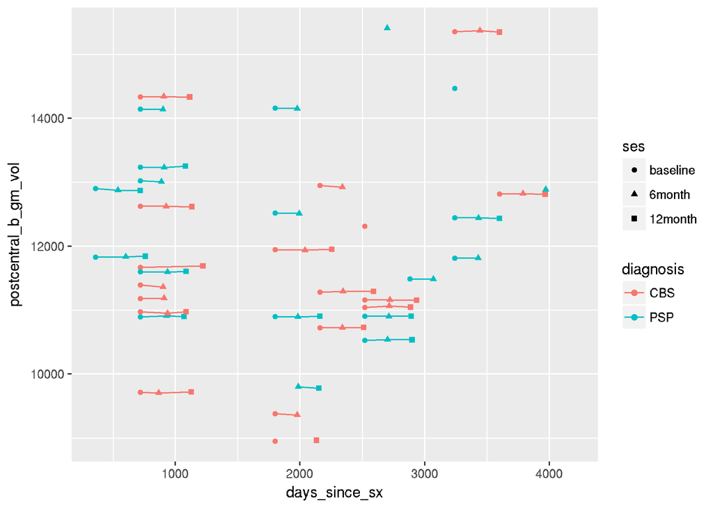

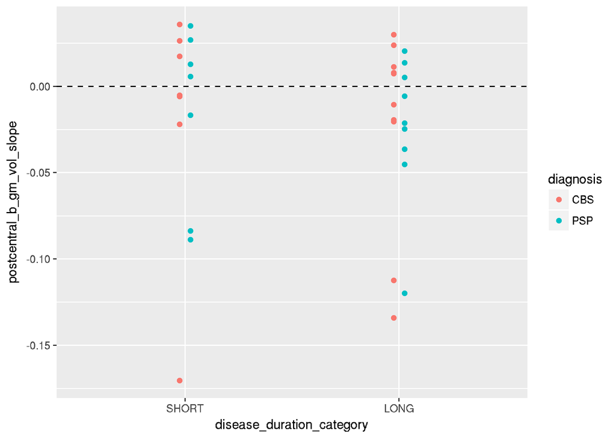

t.test for SHORT vs LONG group diff in slope among CBS:

```r
t.test(postcentral_b_gm_vol_slope~disease_duration_category, data=mydata_long,subset= diagnosis=="CBS")$p.value
```

```
## [1] 0.9021901
```

t.test for SHORT vs LONG group diff in slope among PSP:

```r
t.test(postcentral_b_gm_vol_slope~disease_duration_category, data=mydata_long,subset= diagnosis=="PSP")$p.value
```

```
## [1] 0.7380292
```

# Postcentral Grey Matter Thickness

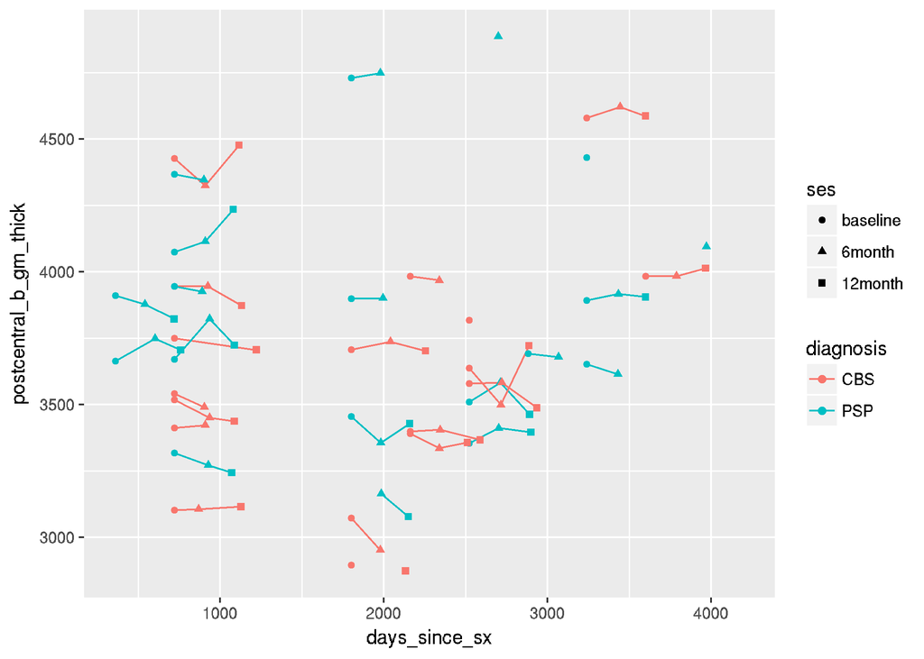

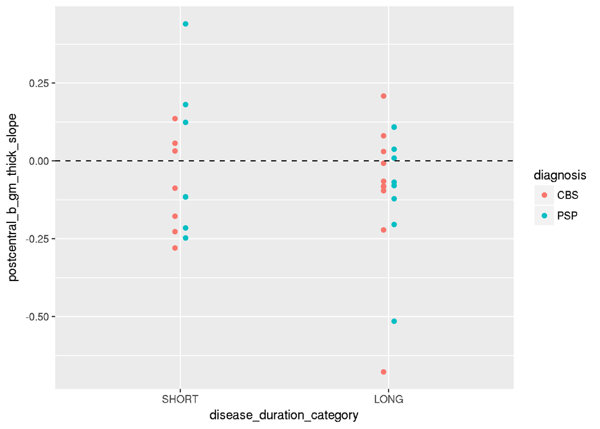

t.test for SHORT vs LONG group diff in slope among CBS:

```r
t.test(postcentral_b_gm_thick_slope~disease_duration_category, data=mydata_long,subset= diagnosis=="CBS")$p.value
```

```
## [1] 0.8936642
```

t.test for SHORT vs LONG group diff in slope among PSP:

```r
t.test(postcentral_b_gm_thick_slope~disease_duration_category, data=mydata_long,subset= diagnosis=="PSP")$p.value
```

```
## [1] 0.458973
```

# Postcentral White Matter Volume

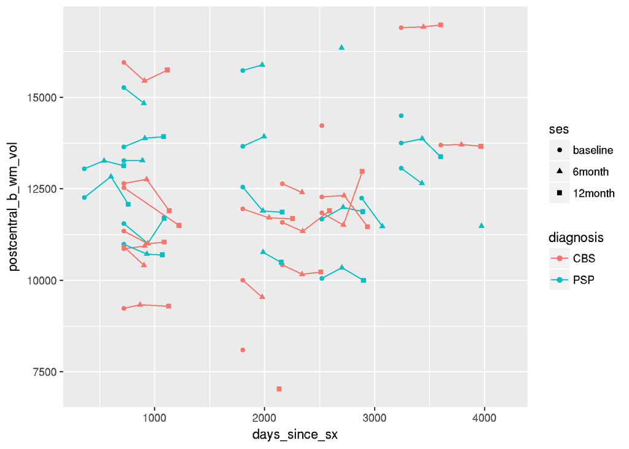

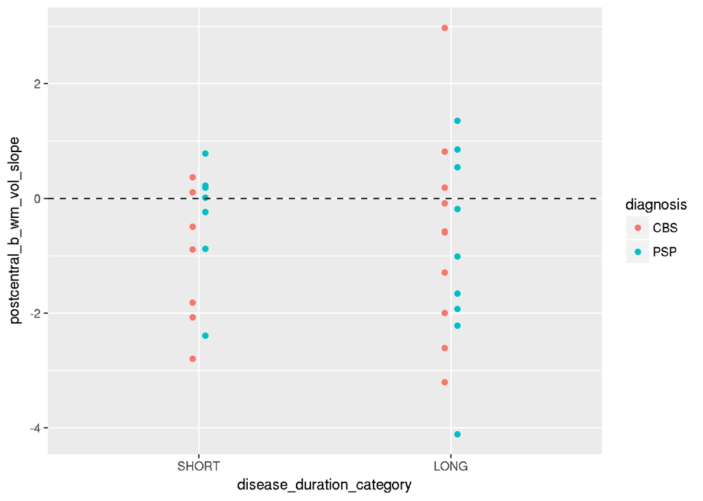

t.test for SHORT vs LONG group diff in slope among CBS:

```r
t.test(postcentral_b_wm_vol_slope~disease_duration_category, data=mydata_long,subset= diagnosis=="CBS")$p.value
```

```
## [1] 0.5450388
```

t.test for SHORT vs LONG group diff in slope among PSP:

```r
t.test(postcentral_b_wm_vol_slope~disease_duration_category, data=mydata_long,subset= diagnosis=="PSP")$p.value
```

```
## [1] 0.4081793
```

# SCP volume

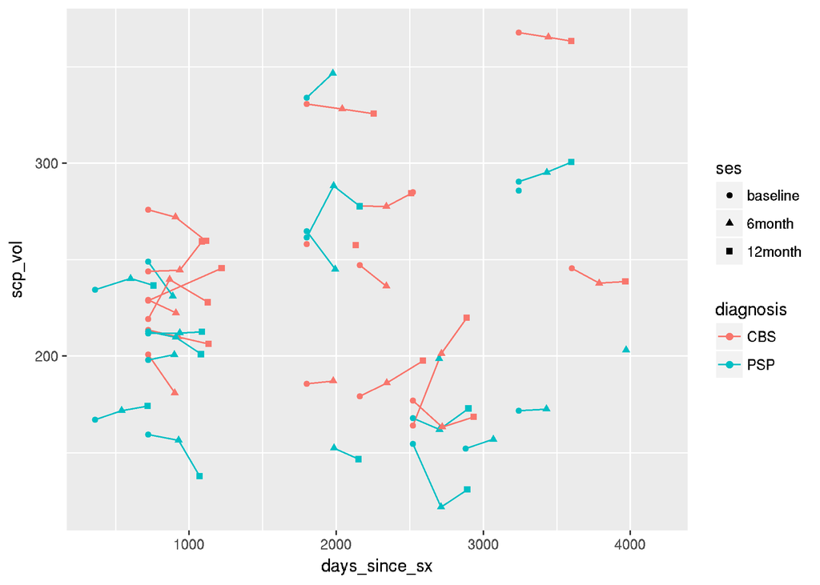

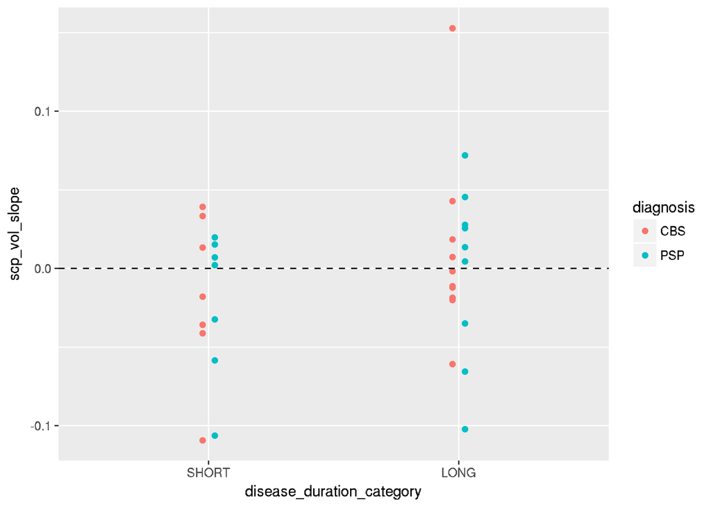

t.test for SHORT vs LONG group diff in slope among CBS:

```r
t.test(scp_vol_slope~disease_duration_category, data=mydata_long,subset= diagnosis=="CBS")$p.value
```

```
## [1] 0.3357956
```

t.test for SHORT vs LONG group diff in slope among PSP:

```r
t.test(scp_vol_slope~disease_duration_category, data=mydata_long,subset= diagnosis=="PSP")$p.value
```

```
## [1] 0.4400818
```

# Midbrain FA

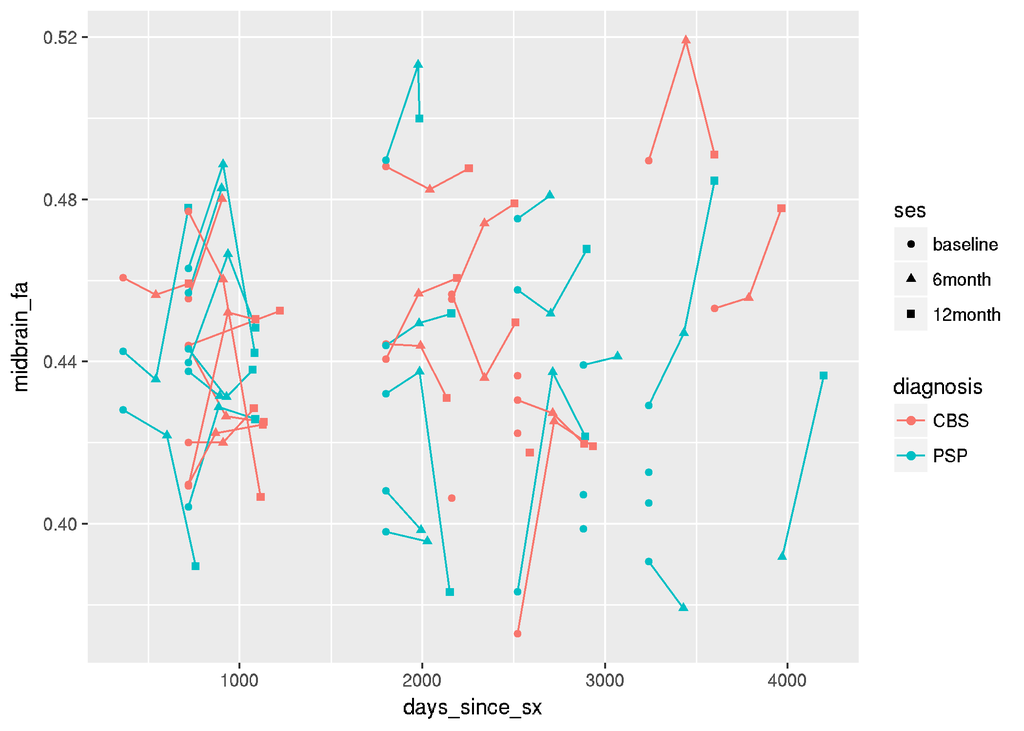

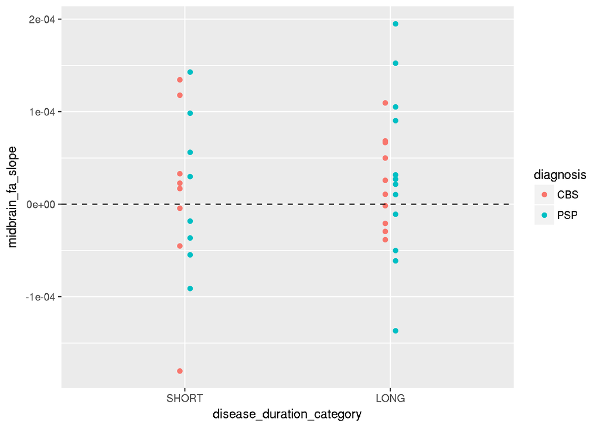

t.test for SHORT vs LONG group diff in slope among CBS:

```r
t.test(midbrain_fa_slope~disease_duration_category, data=mydata_long,subset= diagnosis=="CBS")$p.value
```

```
## [1] 0.7540082
```

t.test for SHORT vs LONG group diff in slope among PSP:

```r
t.test(midbrain_fa_slope~disease_duration_category, data=mydata_long,subset= diagnosis=="PSP")$p.value
```

```
## [1] 0.6984634
```

# Midbrain MD

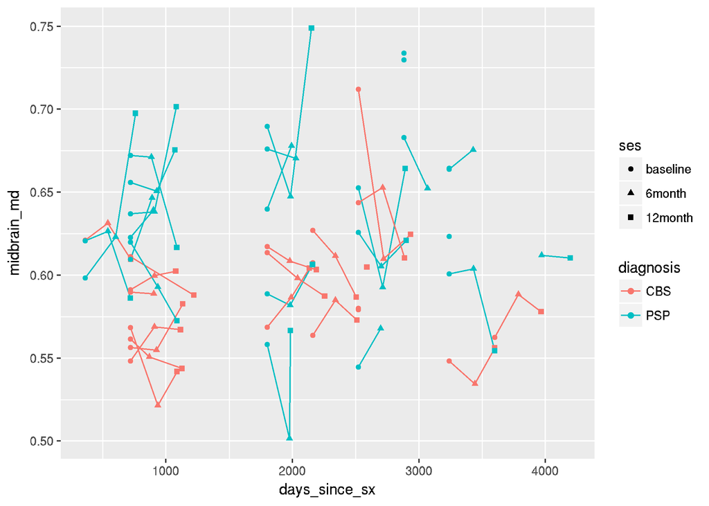

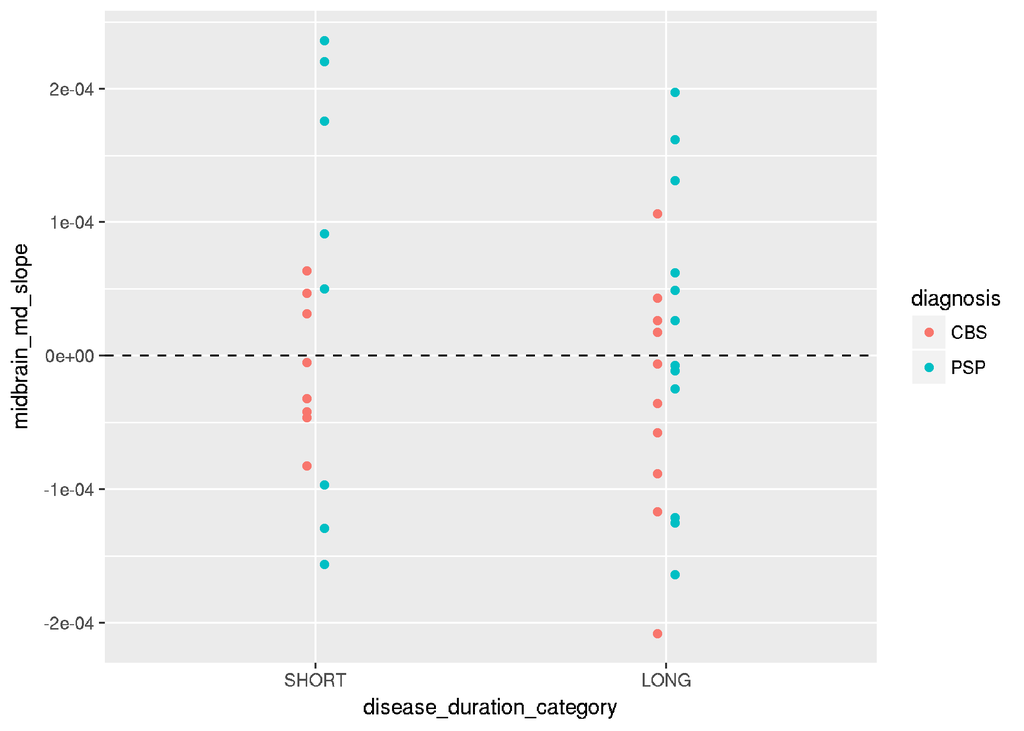

t.test for SHORT vs LONG group diff in slope among CBS:

```r
t.test(midbrain_md_slope~disease_duration_category, data=mydata_long,subset= diagnosis=="CBS")$p.value
```

```
## [1] 0.4955176
```

t.test for SHORT vs LONG group diff in slope among PSP:

```r
t.test(midbrain_md_slope~disease_duration_category, data=mydata_long,subset= diagnosis=="PSP")$p.value
```

```
## [1] 0.607605
```

# Pons FA

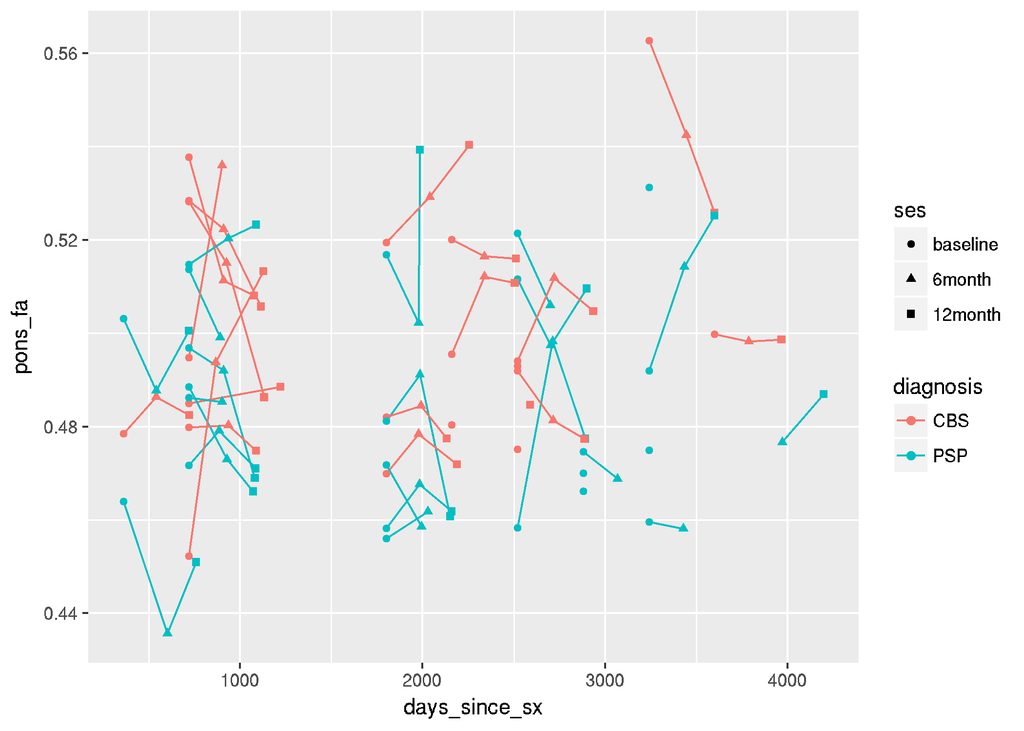

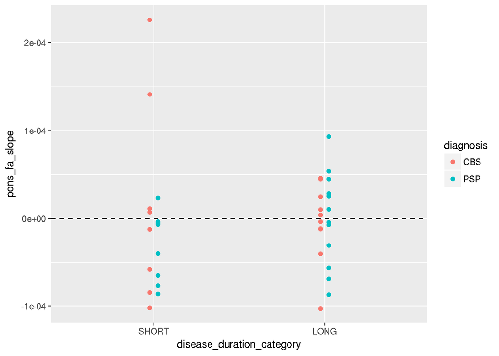

t.test for SHORT vs LONG group diff in slope among CBS:

```r
t.test(pons_fa_slope~disease_duration_category, data=mydata_long,subset= diagnosis=="CBS")$p.value
```

```
## [1] 0.6461621
```

t.test for SHORT vs LONG group diff in slope among PSP:

```r
t.test(pons_fa_slope~disease_duration_category, data=mydata_long,subset= diagnosis=="PSP")$p.value
```

```
## [1] 0.1380589
```

# Pons MD

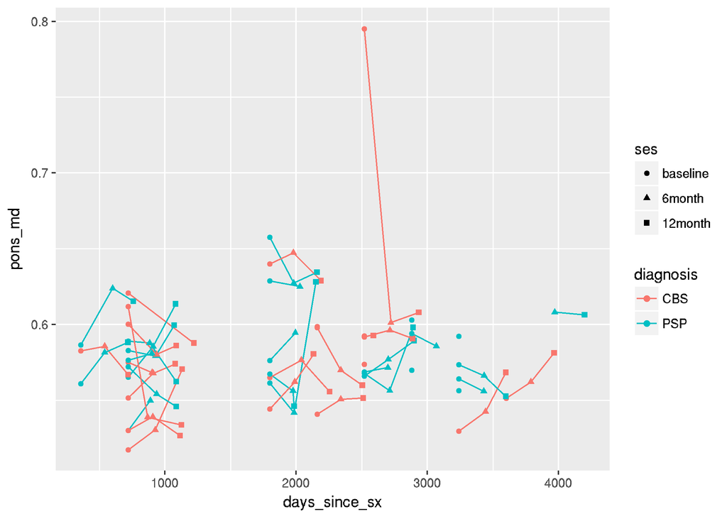

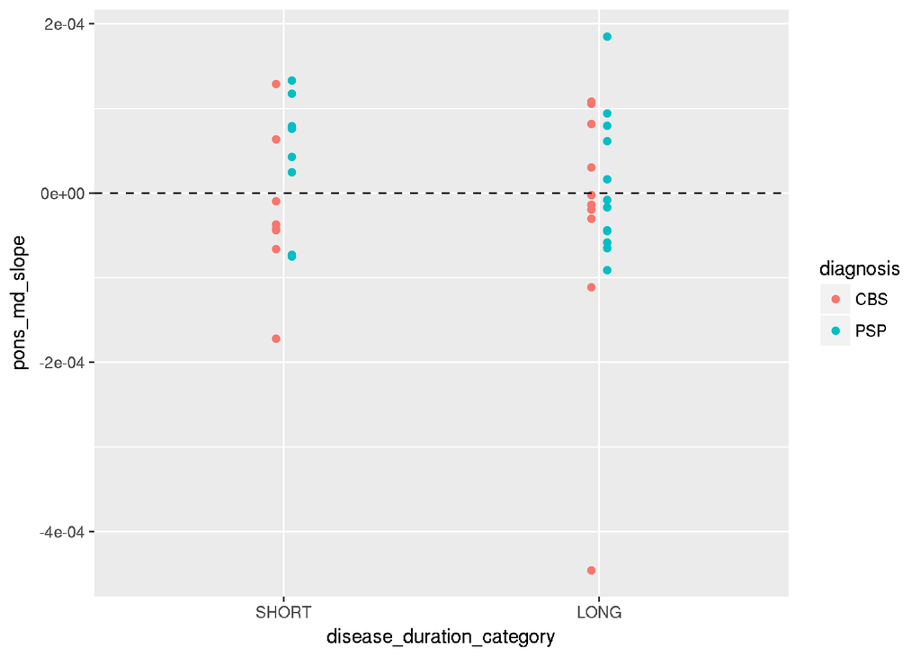

t.test for SHORT vs LONG group diff in slope among CBS:

```r
t.test(pons_md_slope~disease_duration_category, data=mydata_long,subset= diagnosis=="CBS")$p.value
```

```
## [1] 0.904779
```

t.test for SHORT vs LONG group diff in slope among PSP:

```r
t.test(pons_md_slope~disease_duration_category, data=mydata_long,subset= diagnosis=="PSP")$p.value
```

```
## [1] 0.4011142
```

# Pons Volume

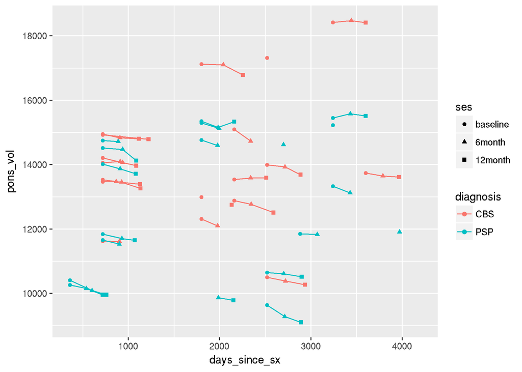

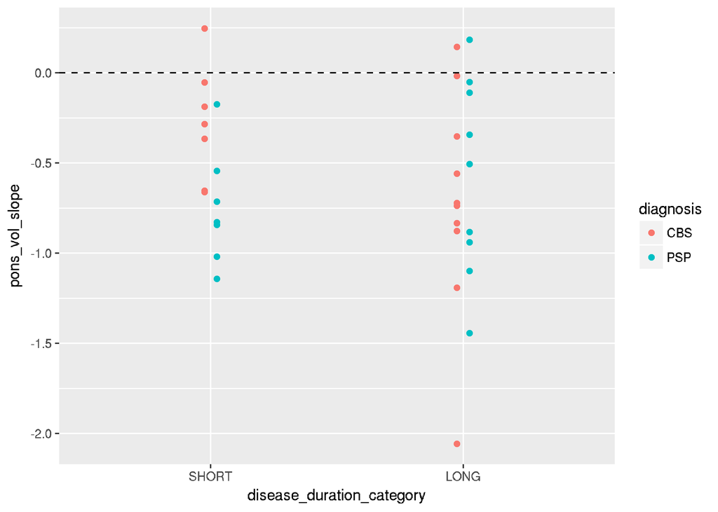

t.test for SHORT vs LONG group diff in slope among CBS:

```r
t.test(pons_vol_slope~disease_duration_category, data=mydata_long,subset= diagnosis=="CBS")$p.value
```

```
## [1] 0.07680427
```

t.test for SHORT vs LONG group diff in slope among PSP:

```r
t.test(pons_vol_slope~disease_duration_category, data=mydata_long,subset= diagnosis=="PSP")$p.value
```

```
## [1] 0.4369317
```

# Caudate MD

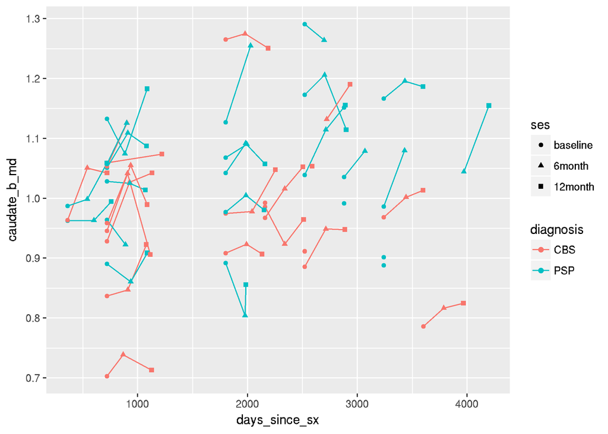

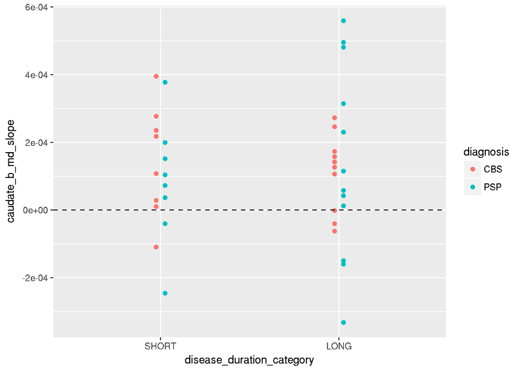

t.test for SHORT vs LONG group diff in slope among CBS:

```r
t.test(caudate_b_md_slope~disease_duration_category, data=mydata_long,subset= diagnosis=="CBS")$p.value
```

```
## [1] 0.6359027
```

t.test for SHORT vs LONG group diff in slope among PSP:

```r
t.test(caudate_b_md_slope~disease_duration_category, data=mydata_long,subset= diagnosis=="PSP")$p.value
```

```
## [1] 0.5920198
```

# Caudate Volume

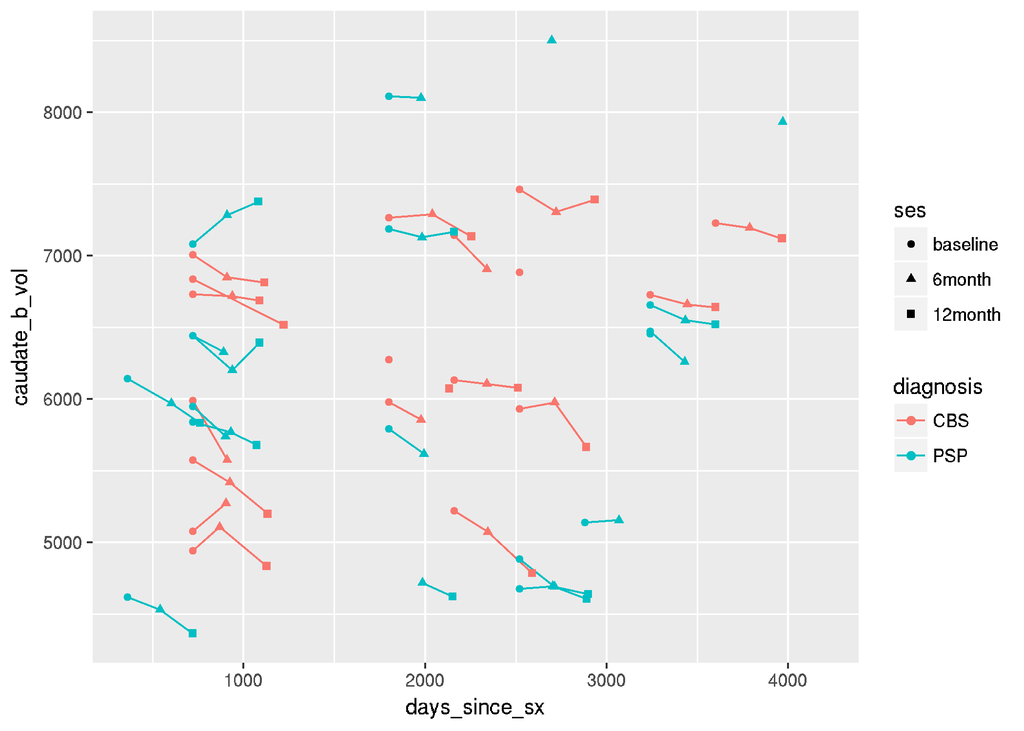

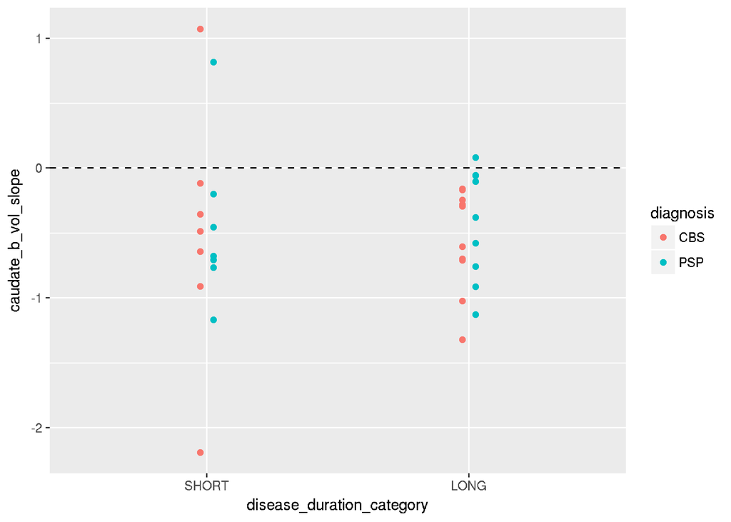

t.test for SHORT vs LONG group diff in slope among CBS:

```r
t.test(caudate_b_vol_slope~disease_duration_category, data=mydata_long,subset= diagnosis=="CBS")$p.value
```

```
## [1] 0.9364953
```

t.test for SHORT vs LONG group diff in slope among PSP:

```r
t.test(caudate_b_vol_slope~disease_duration_category, data=mydata_long,subset= diagnosis=="PSP")$p.value
```

```
## [1] 0.9497582
```

# Demographic Tables

for PSP

```r
demo_table_PSP
```

```
##                                     Stratified by disease_duration_category
##                                      SHORT         LONG          p      test
##   n                                      8            12
##   age_at_baseline (mean (sd))        66.12 (8.59)  71.64 (7.84)   0.164
##   sex_baseline = M (%)                   3 (37.5)      4 (36.4)   1.000
##   EDUCATION (mean (sd))              13.88 (1.55)  16.08 (3.82)   0.141
##   CDR_0_CDRTOT (mean (sd))            0.62 (0.23)   0.71 (0.58)   0.707
##   CDR_0_BOXSCORE (mean (sd))          3.50 (2.00)   4.21 (3.31)   0.595
##   PSPRS_0_TOTAL (mean (sd))          23.75 (5.04)  42.10 (15.43)  0.005
##   MOCA_0_MOCATOTWITHEDUC (mean (sd)) 23.00 (2.62)  20.00 (5.79)   0.222
```

for CBS

```r
demo_table_CBS
```

```
##                                     Stratified by disease_duration_category
##                                      SHORT         LONG          p      test
##   n                                      8            10
##   age_at_baseline (mean (sd))        62.25 (5.28)  67.10 (6.97)   0.123
##   sex_baseline = M (%)                   4 (50.0)      4 (40.0)   1.000
##   EDUCATION (mean (sd))              20.38 (4.60)  16.00 (2.49)   0.020
##   CDR_0_CDRTOT (mean (sd))            0.56 (0.32)   0.55 (0.37)   0.941
##   CDR_0_BOXSCORE (mean (sd))          2.62 (2.08)   2.90 (2.12)   0.786
##   PSPRS_0_TOTAL (mean (sd))          19.88 (6.73)  23.78 (12.07)  0.432
##   MOCA_0_MOCATOTWITHEDUC (mean (sd)) 21.50 (6.83)  20.00 (7.46)   0.707
```

# raw values tables

for PSP

```r
print(PSP_table,digits=6)
```

```
##                                     Stratified by disease_duration_category
##                                      SHORT                    LONG                     p      test
##   n                                  8                        12
##   total_wm_vol_slope_mo (mean (sd))  -620.876427 (693.791632) -496.969589 (801.663354)  0.750
##   total_gm_vol_slope (mean (sd))      -24.466584 (16.838069)    -8.880236 (23.869820)   0.166
##   midbrain_vol_slope (mean (sd))       -0.137569 (0.353391)     -0.272465 (0.442197)    0.521
##   precentral_b_fa_slope (mean (sd))    -0.000042 (0.000022)     -0.000003 (0.000026)    0.003
##   postcentral_b_fa_slope (mean (sd))   -0.000043 (0.000034)      0.000001 (0.000029)    0.021
##   scp_b_fa_slope (mean (sd))           -0.000097 (0.000087)     -0.000066 (0.000115)    0.528
##   scp_vol_slope (mean (sd))            -0.021824 (0.046781)     -0.001451 (0.055665)    0.450
```

for CBS

```r
print(CBS_table,digits=6)
```

```
##                                     Stratified by disease_duration_category
##                                      SHORT                    LONG                     p      test
##   n                                  8                        10
##   total_wm_vol_slope_mo (mean (sd))  -878.966054 (640.379557) -667.498427 (584.739061)  0.491
##   total_gm_vol_slope (mean (sd))      -28.325414 (15.635551)   -24.026411 (26.476618)   0.707
##   midbrain_vol_slope (mean (sd))       -0.036912 (0.306542)     -0.413877 (0.362512)    0.041
##   precentral_b_fa_slope (mean (sd))    -0.000009 (0.000033)     -0.000014 (0.000030)    0.746
##   postcentral_b_fa_slope (mean (sd))   -0.000014 (0.000026)     -0.000007 (0.000022)    0.680
##   scp_b_fa_slope (mean (sd))           -0.000008 (0.000154)     -0.000028 (0.000060)    0.717
##   scp_vol_slope (mean (sd))            -0.016802 (0.051761)      0.009747 (0.057112)    0.343
```

All, split by disease duration group

```r
print(LS_table,digits=6)
```

```
##                                     Stratified by disease_duration_category
##                                      SHORT                    LONG                     p      test
##   n                                  16                       22
##   total_wm_vol_slope_mo (mean (sd))  -749.921240 (655.258770) -586.721609 (681.352363)  0.495
##   total_gm_vol_slope (mean (sd))      -26.395999 (15.738398)   -16.851907 (25.770258)   0.230
##   midbrain_vol_slope (mean (sd))       -0.087240 (0.322082)     -0.346892 (0.397336)    0.054
##   precentral_b_fa_slope (mean (sd))    -0.000026 (0.000032)     -0.000008 (0.000028)    0.088
##   postcentral_b_fa_slope (mean (sd))   -0.000028 (0.000033)     -0.000002 (0.000026)    0.037
##   scp_b_fa_slope (mean (sd))           -0.000053 (0.000129)     -0.000049 (0.000094)    0.913
##   scp_vol_slope (mean (sd))            -0.019313 (0.047470)      0.004442 (0.055146)    0.205
```

All, split by diagnosis

```r
print(diag_table,digits=6)
```

```
##                                     Stratified by Diagnosis
##                                      CBS                      PSP                      p      test
##   n                                  18                       20
##   total_wm_vol_slope_mo (mean (sd))  -754.573332 (598.013849) -551.178831 (734.386188)  0.388
##   total_gm_vol_slope (mean (sd))      -25.796589 (22.152912)   -15.699263 (21.932964)   0.198
##   midbrain_vol_slope (mean (sd))       -0.258656 (0.381745)     -0.213448 (0.398770)    0.742
##   precentral_b_fa_slope (mean (sd))    -0.000012 (0.000031)     -0.000019 (0.000031)    0.516
##   postcentral_b_fa_slope (mean (sd))   -0.000011 (0.000024)     -0.000022 (0.000038)    0.398
##   scp_b_fa_slope (mean (sd))           -0.000019 (0.000108)     -0.000079 (0.000104)    0.092
##   scp_vol_slope (mean (sd))            -0.001185 (0.054962)     -0.010365 (0.051351)    0.624
```